# Assessment 1

Mungunchimeg Batbayar s4662982

2022-03-12

**PART 1**

*RMarkdown editing*

R Markdown is used for creating efficient records of data analysis. R Markdown has 2 steps:

**1.** *Creation*:To create an RMarkdown file (.rmd), you use conventional Markdown syntax alongside chunks of code written in R

**2.** *Knit*: the Markdown formatting and the R code are evaluated, and an output file (HTML, PDF, etc) is produced.

Resource: [Click here](https://ourcodingclub.github.io/tutorials/rmarkdown/)

This is link the how to insert the link in the .rmd file [Click here](https://rmarkdown.rstudio.com/lesson-8.html)

*Load the packages and data set*

```r
#install.packages("tidyverse")
library(tidyverse)
library(knitr)

fastfood <- read_csv("https://raw.githubusercontent.com/rfordatascience/tidytuesday/master/data/2018/2018-09-04/fastfood_calories.csv")
```

```
## * `` -> ...1
```

```r
head(fastfood, 10)
```

```
## # A tibble: 10 x 18
##     ...1 restaurant item            calories cal_fat total_fat sat_fat trans_fat
##    <dbl> <chr>      <chr>              <dbl>   <dbl>     <dbl>   <dbl>     <dbl>
##  1     1 Mcdonalds  Artisan Grille~      380      60         7       2       0
##  2     2 Mcdonalds  Single Bacon S~      840     410        45      17       1.5
##  3     3 Mcdonalds  Double Bacon S~     1130     600        67      27       3
##  4     4 Mcdonalds  Grilled Bacon ~      750     280        31      10       0.5
##  5     5 Mcdonalds  Crispy Bacon S~      920     410        45      12       0.5
##  6     6 Mcdonalds  Big Mac              540     250        28      10       1
##  7     7 Mcdonalds  Cheeseburger         300     100        12       5       0.5
##  8     8 Mcdonalds  Classic Chicke~      510     210        24       4       0
##  9     9 Mcdonalds  Double Cheeseb~      430     190        21      11       1
## 10    10 Mcdonalds  Double Quarter~      770     400        45      21       2.5
## # ... with 10 more variables: cholesterol <dbl>, sodium <dbl>,
## #   total_carb <dbl>, fiber <dbl>, sugar <dbl>, protein <dbl>, vit_a <dbl>,
## #   vit_c <dbl>, calcium <dbl>, salad <chr>
```

```r
kable(fastfood[1:10, 1:5])
```

| …1 | restaurant | item | calories | cal_fat |
| --- | --- | --- | --- | --- |
| 1 | Mcdonalds | Artisan Grilled Chicken Sandwich | 380 | 60 |
| 2 | Mcdonalds | Single Bacon Smokehouse Burger | 840 | 410 |
| 3 | Mcdonalds | Double Bacon Smokehouse Burger | 1130 | 600 |
| 4 | Mcdonalds | Grilled Bacon Smokehouse Chicken Sandwich | 750 | 280 |
| 5 | Mcdonalds | Crispy Bacon Smokehouse Chicken Sandwich | 920 | 410 |
| 6 | Mcdonalds | Big Mac | 540 | 250 |
| 7 | Mcdonalds | Cheeseburger | 300 | 100 |
| 8 | Mcdonalds | Classic Chicken Sandwich | 510 | 210 |
| 9 | Mcdonalds | Double Cheeseburger | 430 | 190 |
| 10 | Mcdonalds | Double Quarter Pounder® with Cheese | 770 | 400 |

**PART 2**

```r
#install.packages("tidyverse")
library(tidyverse)
library(knitr)
library(tidyr)
library(dplyr)
library(skimr)
```

**Task-8**

```r
fastfood %>%
  filter(calories >= 1000) %>%
  arrange(calories)
```

```
## # A tibble: 32 x 18
##     ...1 restaurant  item           calories cal_fat total_fat sat_fat trans_fat
##    <dbl> <chr>       <chr>             <dbl>   <dbl>     <dbl>   <dbl>     <dbl>
##  1   115 Sonic       Buffalo Dunke~     1000     550        61      12       0.5
##  2   194 Burger King Bacon & Swiss~     1000     585        65      24       3
##  3   263 Dairy Queen 1/2 lb. Flame~     1000     660        74      26       2
##  4   312 Subway      Footlong Big ~     1000     300        34      18       2
##  5   176 Arbys       Triple Decker~     1030     459        51      17       1
##  6   270 Dairy Queen 4 Piece Chick~     1030     480        53       9       1
##  7   197 Burger King Bacon King         1040     630        48      28       2.5
##  8   281 Dairy Queen Large Cheese ~     1050     670        75      43       1
##  9   122 Sonic       4 Piece Super~     1080     460        51       9       1
## 10   199 Burger King BBQ Bacon King     1100     675        75      29       3
## # ... with 22 more rows, and 10 more variables: cholesterol <dbl>,
## #   sodium <dbl>, total_carb <dbl>, fiber <dbl>, sugar <dbl>, protein <dbl>,
## #   vit_a <dbl>, vit_c <dbl>, calcium <dbl>, salad <chr>
```

**Task-9**

```r
dont_eat_this <- fastfood %>%
  filter(total_fat >=40, total_carb >=80) %>%
  arrange(desc(total_carb))
```

**Task-10**

```r
heavy_food <- fastfood %>%
  mutate(heavy_food = case_when(calories>500 ~ "heavy", calories<250 ~ "low", TRUE ~ "average"))
```

**Task-11**

```r
library(skimr)
skim(fastfood)
```

Data summary

| Name | fastfood |
| --- | --- |
| Number of rows | 515 |
| Number of columns | 18 |
| _______________________ |  |
| Column type frequency: |  |
| character | 3 |
| numeric | 15 |
| ________________________ |  |
| Group variables | None |

**Variable type: character**

| skim_variable | n_missing | complete_rate | min | max | empty | n_unique | whitespace |
| --- | --- | --- | --- | --- | --- | --- | --- |
| restaurant | 0 | 1 | 5 | 11 | 0 | 8 | 0 |
| item | 0 | 1 | 5 | 63 | 0 | 505 | 0 |
| salad | 0 | 1 | 5 | 5 | 0 | 1 | 0 |

**Variable type: numeric**

| skim_variable | n_missing | complete_rate | mean | sd | p0 | p25 | p50 | p75 | p100 | hist |
| --- | --- | --- | --- | --- | --- | --- | --- | --- | --- | --- |
| …1 | 0 | 1.00 | 258.00 | 148.81 | 1 | 129.5 | 258.0 | 386.5 | 515 | ▇▇▇▇▇ |
| calories | 0 | 1.00 | 530.91 | 282.44 | 20 | 330.0 | 490.0 | 690.0 | 2430 | ▇▆▁▁▁ |
| cal_fat | 0 | 1.00 | 238.81 | 166.41 | 0 | 120.0 | 210.0 | 310.0 | 1270 | ▇▃▁▁▁ |
| total_fat | 0 | 1.00 | 26.59 | 18.41 | 0 | 14.0 | 23.0 | 35.0 | 141 | ▇▃▁▁▁ |
| sat_fat | 0 | 1.00 | 8.15 | 6.42 | 0 | 4.0 | 7.0 | 11.0 | 47 | ▇▃▁▁▁ |
| trans_fat | 0 | 1.00 | 0.47 | 0.84 | 0 | 0.0 | 0.0 | 1.0 | 8 | ▇▁▁▁▁ |
| cholesterol | 0 | 1.00 | 72.46 | 63.16 | 0 | 35.0 | 60.0 | 95.0 | 805 | ▇▁▁▁▁ |
| sodium | 0 | 1.00 | 1246.74 | 689.95 | 15 | 800.0 | 1110.0 | 1550.0 | 6080 | ▇▆▁▁▁ |
| total_carb | 0 | 1.00 | 45.66 | 24.88 | 0 | 28.5 | 44.0 | 57.0 | 156 | ▅▇▂▁▁ |
| fiber | 12 | 0.98 | 4.14 | 3.04 | 0 | 2.0 | 3.0 | 5.0 | 17 | ▇▅▂▁▁ |
| sugar | 0 | 1.00 | 7.26 | 6.76 | 0 | 3.0 | 6.0 | 9.0 | 87 | ▇▁▁▁▁ |
| protein | 1 | 1.00 | 27.89 | 17.68 | 1 | 16.0 | 24.5 | 36.0 | 186 | ▇▂▁▁▁ |
| vit_a | 214 | 0.58 | 18.86 | 31.38 | 0 | 4.0 | 10.0 | 20.0 | 180 | ▇▁▁▁▁ |
| vit_c | 210 | 0.59 | 20.17 | 30.59 | 0 | 4.0 | 10.0 | 30.0 | 400 | ▇▁▁▁▁ |
| calcium | 210 | 0.59 | 24.85 | 25.52 | 0 | 8.0 | 20.0 | 30.0 | 290 | ▇▁▁▁▁ |

**Task-12**

```r
fastfood %>%
  count(restaurant) %>%
  arrange(desc(n))
```

```
## # A tibble: 8 x 2
##   restaurant      n
##   <chr>       <int>
## 1 Taco Bell     115
## 2 Subway         96
## 3 Burger King    70
## 4 Mcdonalds      57
## 5 Arbys          55
## 6 Sonic          53
## 7 Dairy Queen    42
## 8 Chick Fil-A    27
```

**Task-13**

```r
fastfood %>%
  group_by(restaurant) %>%
  summarise(average_calories = mean(calories)) %>%
  ungroup()
```

```
## # A tibble: 8 x 2
##   restaurant  average_calories
##   <chr>                  <dbl>
## 1 Arbys                   533.
## 2 Burger King             609.
## 3 Chick Fil-A             384.
## 4 Dairy Queen             520.
## 5 Mcdonalds               640.
## 6 Sonic                   632.
## 7 Subway                  503.
## 8 Taco Bell               444.
```

**Task-14**

*1.The average calories of each restaurant*

```r
average_calories <- fastfood %>%
  group_by(restaurant) %>%
  summarise(average_calories = mean(calories)) %>%
  ungroup() %>%
  arrange(desc(average_calories)) %>%
  mutate_if(is.numeric, round, digits = 2)
```

*2.The maximum total fat of each restaurant*

```r
max_fat <- fastfood %>%
  group_by(restaurant) %>%
  summarise(total_fat = max(total_fat)) %>%
  ungroup() %>%
  arrange(desc(total_fat))
```

*3.The minimum cholesterol of each restaurant*

```r
min_cholesterol <- fastfood %>%
  group_by(restaurant) %>%
  summarise(cholesterol = min(cholesterol)) %>%
  ungroup() %>%
  arrange(cholesterol)
```

**Task-15**

Total fat of each restaurant:

```r
total_fat_per_restaurant <- fastfood %>%
  group_by(restaurant) %>%
  summarise(total_fat = sum(total_fat)) %>%
  ungroup() %>%
  arrange(total_fat)
```

Figure 1a and Figure 1b show the total fat per restaurant. Based on 2 variables which are one discrete and another is continuous, geom_col() function is chosen in Figure 1a, and geom_point function with geom_line is chosen in Figure 1b. In addition, text label and reorder functions are used.

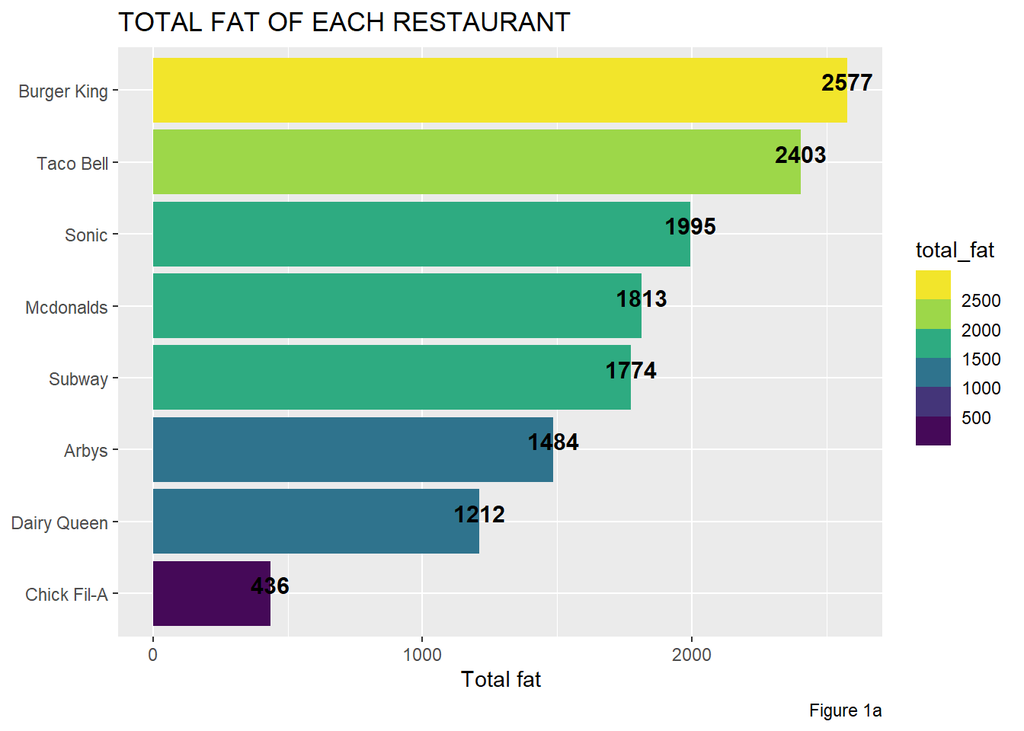

```r
total_fat_per_restaurant %>%
  mutate(restaurant = fct_reorder(restaurant, total_fat)) %>%
  ggplot(aes(restaurant, total_fat, group = 1, fill = total_fat)) +
  geom_col() +
  scale_fill_viridis_b() +
  coord_flip() +
  geom_text(aes(label = total_fat), fontface = "bold", size = 4, vjust = 0) +
  labs(x = NULL, y = "Total fat",
       title = "TOTAL FAT OF EACH RESTAURANT", caption = "Figure 1a")
```

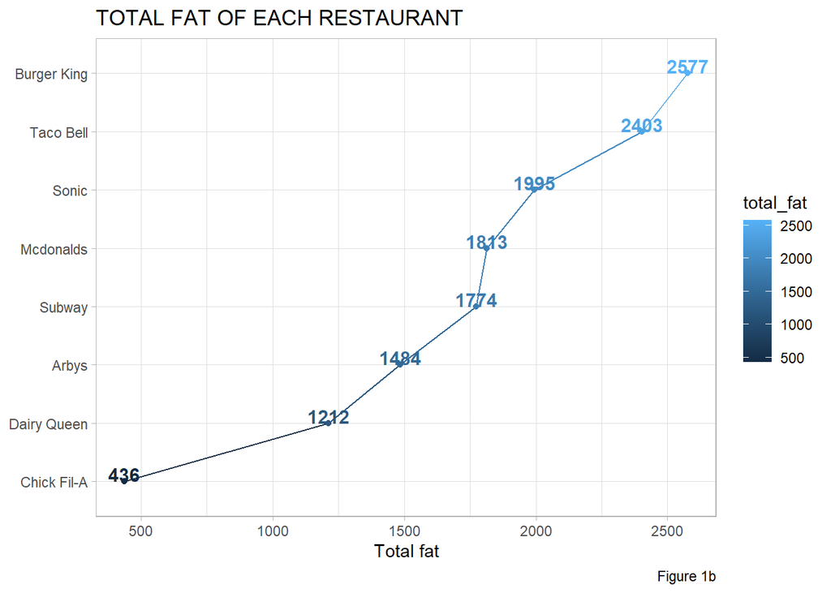

```r
total_fat_per_restaurant %>%
  mutate(restaurant = fct_reorder(restaurant, total_fat)) %>%
  ggplot(aes(restaurant, total_fat, group = 1, color = total_fat)) +
  geom_line() +
  geom_point() +
      coord_flip() +
  geom_text(aes(label = total_fat), fontface = "bold", size = 4, vjust = 0) +
    labs(x = NULL, y = "Total fat",
       title = "TOTAL FAT OF EACH RESTAURANT", caption = "Figure 1b") +
        theme_light()
```

**Task-16**

```r
new_fastfood <- fastfood %>%
  mutate(cholesterol_sodium = cholesterol + sodium)

new_fastfood$salad <- NULL
```

**Task-17**

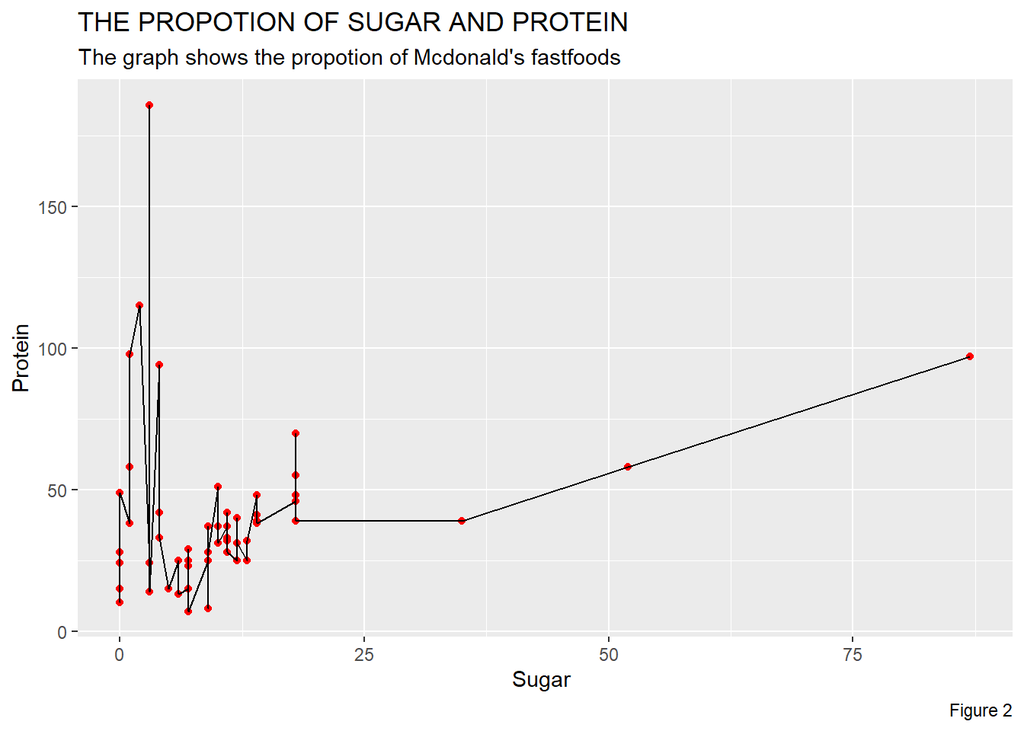

```r
Mcdonalds <- fastfood %>%
    select(restaurant, item, sugar, protein) %>%
  filter(restaurant == "Mcdonalds")


Mcdonalds %>%
  ggplot(aes(sugar, protein)) +
  geom_point(colour = "red") +
  geom_line() +
  labs(x = "Sugar ", y = "Protein",
       title = "THE PROPOTION OF SUGAR AND PROTEIN",
       subtitle = "The graph shows the propotion of Mcdonald's fastfoods", caption = "Figure 2") +
  theme_gray()
```

**PART 3**

**Task-18**

```r
skim(fastfood)
```

Data summary

| Name | fastfood |
| --- | --- |
| Number of rows | 515 |
| Number of columns | 18 |
| _______________________ |  |
| Column type frequency: |  |
| character | 3 |
| numeric | 15 |
| ________________________ |  |
| Group variables | None |

**Variable type: character**

| skim_variable | n_missing | complete_rate | min | max | empty | n_unique | whitespace |
| --- | --- | --- | --- | --- | --- | --- | --- |
| restaurant | 0 | 1 | 5 | 11 | 0 | 8 | 0 |
| item | 0 | 1 | 5 | 63 | 0 | 505 | 0 |
| salad | 0 | 1 | 5 | 5 | 0 | 1 | 0 |

**Variable type: numeric**

| skim_variable | n_missing | complete_rate | mean | sd | p0 | p25 | p50 | p75 | p100 | hist |
| --- | --- | --- | --- | --- | --- | --- | --- | --- | --- | --- |
| …1 | 0 | 1.00 | 258.00 | 148.81 | 1 | 129.5 | 258.0 | 386.5 | 515 | ▇▇▇▇▇ |
| calories | 0 | 1.00 | 530.91 | 282.44 | 20 | 330.0 | 490.0 | 690.0 | 2430 | ▇▆▁▁▁ |
| cal_fat | 0 | 1.00 | 238.81 | 166.41 | 0 | 120.0 | 210.0 | 310.0 | 1270 | ▇▃▁▁▁ |
| total_fat | 0 | 1.00 | 26.59 | 18.41 | 0 | 14.0 | 23.0 | 35.0 | 141 | ▇▃▁▁▁ |
| sat_fat | 0 | 1.00 | 8.15 | 6.42 | 0 | 4.0 | 7.0 | 11.0 | 47 | ▇▃▁▁▁ |
| trans_fat | 0 | 1.00 | 0.47 | 0.84 | 0 | 0.0 | 0.0 | 1.0 | 8 | ▇▁▁▁▁ |
| cholesterol | 0 | 1.00 | 72.46 | 63.16 | 0 | 35.0 | 60.0 | 95.0 | 805 | ▇▁▁▁▁ |
| sodium | 0 | 1.00 | 1246.74 | 689.95 | 15 | 800.0 | 1110.0 | 1550.0 | 6080 | ▇▆▁▁▁ |
| total_carb | 0 | 1.00 | 45.66 | 24.88 | 0 | 28.5 | 44.0 | 57.0 | 156 | ▅▇▂▁▁ |
| fiber | 12 | 0.98 | 4.14 | 3.04 | 0 | 2.0 | 3.0 | 5.0 | 17 | ▇▅▂▁▁ |
| sugar | 0 | 1.00 | 7.26 | 6.76 | 0 | 3.0 | 6.0 | 9.0 | 87 | ▇▁▁▁▁ |
| protein | 1 | 1.00 | 27.89 | 17.68 | 1 | 16.0 | 24.5 | 36.0 | 186 | ▇▂▁▁▁ |
| vit_a | 214 | 0.58 | 18.86 | 31.38 | 0 | 4.0 | 10.0 | 20.0 | 180 | ▇▁▁▁▁ |
| vit_c | 210 | 0.59 | 20.17 | 30.59 | 0 | 4.0 | 10.0 | 30.0 | 400 | ▇▁▁▁▁ |
| calcium | 210 | 0.59 | 24.85 | 25.52 | 0 | 8.0 | 20.0 | 30.0 | 290 | ▇▁▁▁▁ |

```r
class(fastfood$item)
```

```
## [1] "character"
```

```r
fastfood$item <- as_factor(fastfood$item)

fastfood %>%
  mutate(item = fct_lump(item, n = 10)) %>%
  count(item)
```

```
## # A tibble: 505 x 2
##    item                                          n
##    <fct>                                     <int>
##  1 Artisan Grilled Chicken Sandwich              1
##  2 Single Bacon Smokehouse Burger                1
##  3 Double Bacon Smokehouse Burger                1
##  4 Grilled Bacon Smokehouse Chicken Sandwich     1
##  5 Crispy Bacon Smokehouse Chicken Sandwich      1
##  6 Big Mac                                       1
##  7 Cheeseburger                                  2
##  8 Classic Chicken Sandwich                      1
##  9 Double Cheeseburger                           2
## 10 Double Quarter Pounder® with Cheese           1
## # ... with 495 more rows
```

**Task-19**

```r
updated_fastfood <- fastfood %>%
  mutate(calories_type = cut_number(calories, n = 3, labels = c("low", "med", "high"))) %>%
  arrange(desc(calories_type))
```

**Task-20**

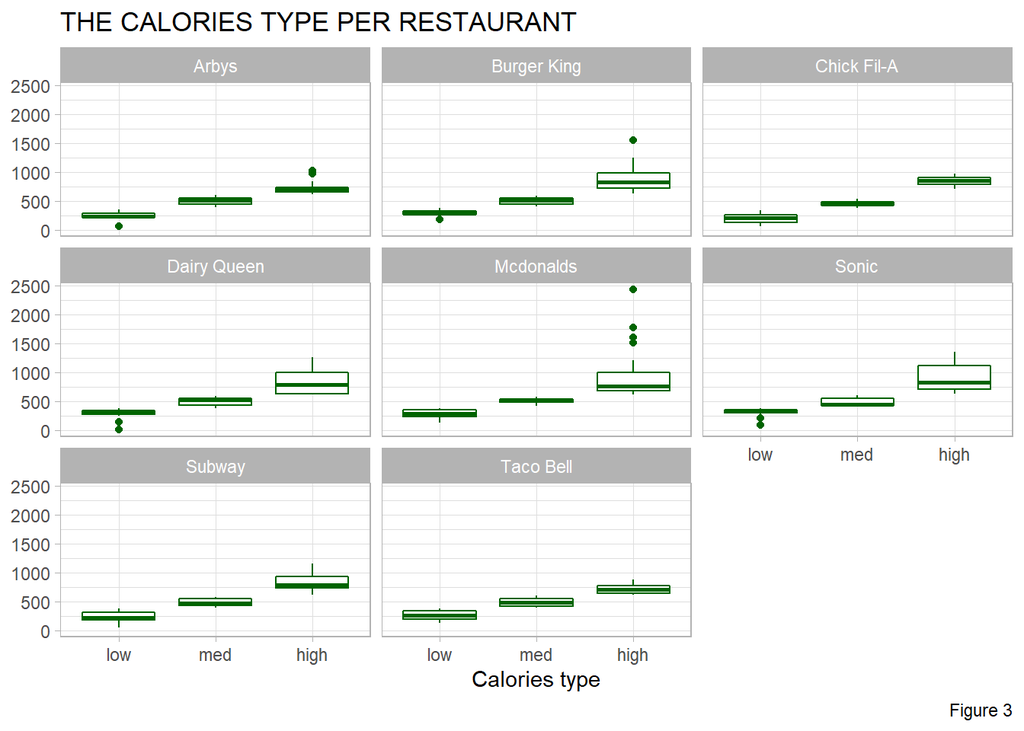

```r
ggplot(updated_fastfood, aes(calories_type, calories)) +
  geom_boxplot(color = "dark green") +
  facet_wrap(~restaurant) +
    theme_light() +
    labs(x = 'Calories type', y = NULL,
          title = 'THE CALORIES TYPE PER RESTAURANT',  caption = 'Figure 3')
```

**Task-21**

```r
trans_fat_per <- fastfood %>%
  mutate(trans_fat_percent = trans_fat/total_fat*100) %>%
  mutate_if(is.numeric,
            round,
            digits = 2)
```

**Task-22**

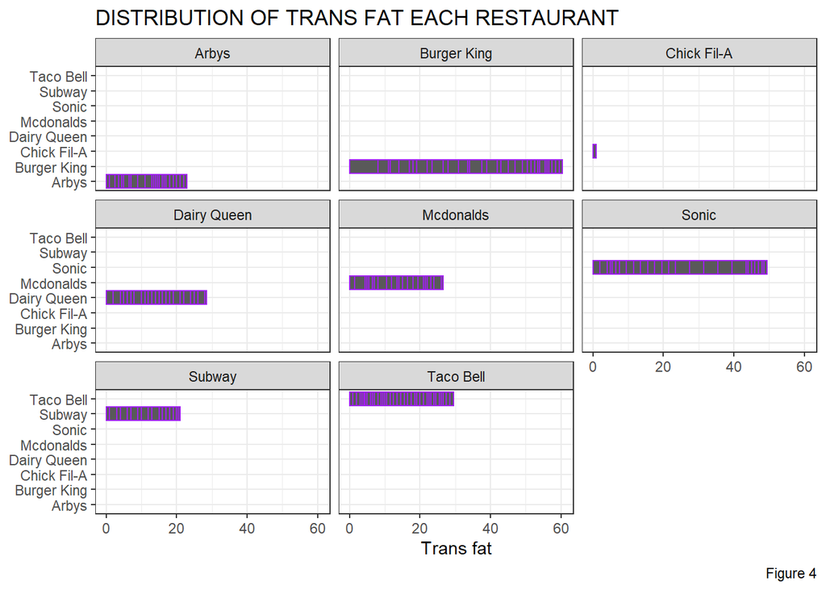

```r
fastfood %>%
  ggplot(aes(restaurant, trans_fat)) +
  geom_col(colour = "purple") +
  facet_wrap(~restaurant) +
  coord_flip() +
  theme_bw() +
  labs(x = NULL, y = 'Trans fat',
       title = "DISTRIBUTION OF TRANS FAT EACH RESTAURANT", caption = "Figure 4")
```

**Task-23**

```r
fastfood %>%
  group_by(restaurant) %>%
  summarise(total_fat = mean(total_fat)) %>%
  ungroup() %>%
  arrange(total_fat)
```

```
## # A tibble: 8 x 2
##   restaurant  total_fat
##   <chr>           <dbl>
## 1 Chick Fil-A      16.1
## 2 Subway           18.5
## 3 Taco Bell        20.9
## 4 Arbys            27.0
## 5 Dairy Queen      28.9
## 6 Mcdonalds        31.8
## 7 Burger King      36.8
## 8 Sonic            37.6
```

**Task-24**

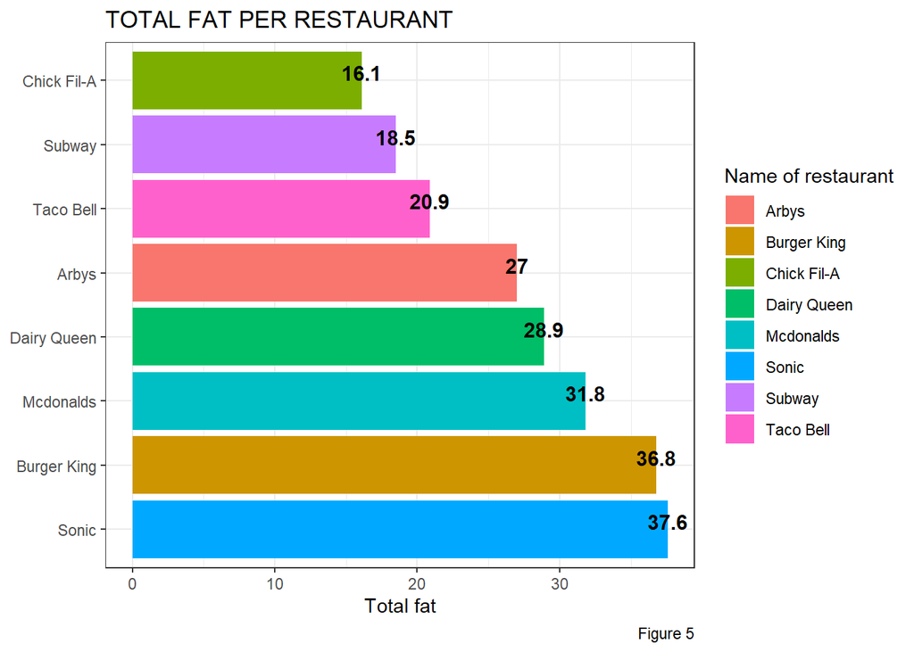

```r
fastfood %>%
  group_by(restaurant) %>%
  summarise(total_fat = mean(total_fat)) %>%
  ungroup() %>%
  arrange(restaurant, total_fat) %>%
  mutate_if(is.numeric, round, digits = 1) %>%
  ggplot(aes(x = reorder(restaurant, - total_fat), y = total_fat, fill = restaurant)) +
  geom_col() +
  geom_text(aes(label = total_fat), fontface = "bold", size = 4, vjust = 0) +
  coord_flip() +
  theme_bw() +
  labs( x = NULL, y = 'Total fat', fill = 'Name of restaurant',
        title = 'TOTAL FAT PER RESTAURANT', caption = 'Figure 5')
```